# Assignment

David F. Severski

Sunday, January 25, 2015

# Objective

## Outcome Variable

| Class | Description |
| --- | --- |
| Class A | Exactly according to the specification |
| Class B | Throwing the elbows to the front |
| Class C | Lifting the dumbbell only halfway |
| Class D | Lowering the dumbbell only halfway |
| Class E | Throwing the hips to the front |

# Data Retrieval

```r
library(dplyr)
library(caret)
```

```r
train_url <- "https://d396qusza40orc.cloudfront.net/predmachlearn/pml-training.csv"
test_url  <- "https://d396qusza40orc.cloudfront.net/predmachlearn/pml-testing.csv"
if (!file.exists("data")) { dir.create("data") }
if (!file.exists("data/pml-train.csv")) {
  download.file(train_url, "data/pml-train.csv")
}
if (!file.exists("data/pml-testing.csv")) {
  download.file(test_url, "data/pml-testing.csv")
}

# load data
na_strings <- c("", "#DIV/0!", "NA")    #consider these strings as NAs
training <- read.csv("data/pml-train.csv", row.names=1,
                     na.strings=na_strings) %>% tbl_df()
testing <- read.csv("data/pml-testing.csv", row.names=1,
                    na.strings=na_strings) %>% tbl_df()
```

## Data Cleanup

Eliminate all columns that are mostly NA in value. Convert the `classe` outcome variable to a factor. We also remove the username and date/time columns as we are not considering time to be a factor in this model.

```r
training$classe <- as.factor(training$classe)

# create variables for our outcome and numeric predictor columns
numeric_cols <- sapply(training, is.numeric)
predictors <- names(training)[numeric_cols]

# easy elimination, get columns that are not all NAs
training <- training[,colSums(is.na(training))<nrow(training)]

# look for columns that are more mostly NAs
na_test <- sapply(training, function(x) {sum(is.na(x))})
#table(na_test)

bad_columns <- names(na_test[na_test>=19216])

#also remove some confounding variables
bad_columns <- c(bad_columns, "user_name", "raw_timestamp_part_1",
                 "raw_timestamp_part_2", "cvtd_timestamp", "num_window")

training = training[, !names(training) %in% bad_columns]
```

Candidate features after data cleansing are: new_window, roll_belt, pitch_belt, yaw_belt, total_accel_belt, gyros_belt_x, gyros_belt_y, gyros_belt_z, accel_belt_x, accel_belt_y, accel_belt_z, magnet_belt_x, magnet_belt_y, magnet_belt_z, roll_arm, pitch_arm, yaw_arm, total_accel_arm, gyros_arm_x, gyros_arm_y, gyros_arm_z, accel_arm_x, accel_arm_y, accel_arm_z, magnet_arm_x, magnet_arm_y, magnet_arm_z, roll_dumbbell, pitch_dumbbell, yaw_dumbbell, total_accel_dumbbell, gyros_dumbbell_x, gyros_dumbbell_y, gyros_dumbbell_z, accel_dumbbell_x, accel_dumbbell_y, accel_dumbbell_z, magnet_dumbbell_x, magnet_dumbbell_y, magnet_dumbbell_z, roll_forearm, pitch_forearm, yaw_forearm, total_accel_forearm, gyros_forearm_x, gyros_forearm_y, gyros_forearm_z, accel_forearm_x, accel_forearm_y, accel_forearm_z, magnet_forearm_x, magnet_forearm_y, magnet_forearm_z, classe

## Partition Data

A new training and validation set is created using 70% of the original training set. A static random seed is set to ensure reproducibility.

```r
set.seed(1337)
inTrain <- createDataPartition(y=training$classe, p=0.7, list=FALSE)
training_clean <- training[inTrain,]
validation_clean <- training[-inTrain,]
```

## Identify Predictors

```r
nonusefullPredictors <- nearZeroVar(training_clean, saveMetrics = T)
eliminatedFeatures <- predictors[nonusefullPredictors$nzv]
usefullFeatures <- predictors[-nonusefullPredictors$nzv]
```

# Train Model

The `doParallel` library is used to distribute model creation load across all CPU cores.

```r
library(doParallel)
registerDoParallel(detectCores())       #consume all available cores
```

Create a random forest model on our training data set using 4-fold cross validation. Note that this is processor intensive. To save rerun time, the model is serialized to disk and stored between runs, if possible.

```r
set.seed(57475)
tc <- trainControl(method="cv", number=4)
if (file.exists("data/model_rf.Rdata")) {
                model_rf <- readRDS("data/model_rf.Rdata")
} else {
  model_rf <- train(classe ~ ., data=training_clean, model="rf", verbose=F,
                    allowParallel=T, importance = T, trControl = tc)
  saveRDS(model_rf, file="data/model_rf.Rdata")         #save for faster resuse
}
```

# Evaluate Model

We take our random forest model and apply it against the validation hold out, generating a confusion matrix of predictions vs. actuals.

```r
validation_pred <- predict(model_rf, newdata=validation_clean)
confusionMatrix(validation_pred, validation_clean$classe)
```

```
## Confusion Matrix and Statistics
##
##           Reference
## Prediction    A    B    C    D    E
##          A 1674    8    0    0    0
##          B    0 1123   10    0    0
##          C    0    8 1016   14    0
##          D    0    0    0  950    1
##          E    0    0    0    0 1081
##
## Overall Statistics
##
##                Accuracy : 0.993
##                  95% CI : (0.9906, 0.995)
##     No Information Rate : 0.2845
##     P-Value [Acc > NIR] : < 2.2e-16
##
##                   Kappa : 0.9912
##  Mcnemar's Test P-Value : NA
##
## Statistics by Class:
##
##                      Class: A Class: B Class: C Class: D Class: E
## Sensitivity            1.0000   0.9860   0.9903   0.9855   0.9991
## Specificity            0.9981   0.9979   0.9955   0.9998   1.0000
## Pos Pred Value         0.9952   0.9912   0.9788   0.9989   1.0000
## Neg Pred Value         1.0000   0.9966   0.9979   0.9972   0.9998
## Prevalence             0.2845   0.1935   0.1743   0.1638   0.1839
## Detection Rate         0.2845   0.1908   0.1726   0.1614   0.1837
## Detection Prevalence   0.2858   0.1925   0.1764   0.1616   0.1837
## Balanced Accuracy      0.9991   0.9919   0.9929   0.9926   0.9995
```

Look at the importance variable

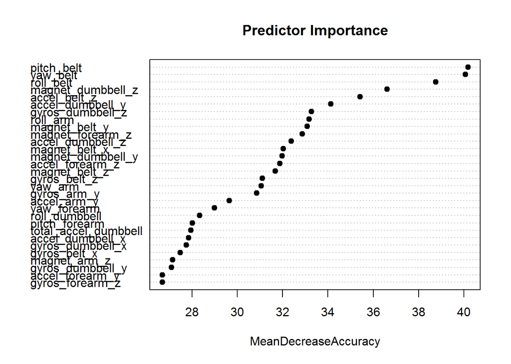

```r
# Check variable for importance
imp <- varImp(model_rf)$importance
varImpPlot(model_rf$finalModel, sort = TRUE, type = 1, pch = 19, col = 1,
           cex = 1, main = "Predictor Importance")
```

# Final Predictions on Test Data Set

Create our final predictions on the testing data and output our answer files using the supplied function.

```r
predictions <- predict(model_rf, testing)
#confusionMatrix(predictions, testing$classe)

pml_write_files = function(x){
  n = length(x)
  for(i in 1:n){
    filename  <- paste0("problem_id_", i, ".txt")
    write.table(x[i], file=filename, quote=FALSE,
                row.names=FALSE, col.names=FALSE)
  }
}

pml_write_files(predictions)
```

# Credits

Thank you to the authors of http://groupware.les.inf.puc-rio.br/ha for permitting this data to be used for this assignment.